# Curve-fitting Known Data for Vapor Pressure

Scott Haraburda

March 1, 1996

## Purpose.

To use simple and quick techniques to estimate vapor pressures using known data. This includes a quick estimate using the Antoine equation, and a more rigorous estimation using the Newton_Raphson method. This includes the script for my *Chemical Engineering* article[^1].

## Vapor Pressure

Vapor pressures for pure liquid chemicals are important for designing equipment intended for separation of liquid mixtures. The following method provides a useful way to develop an equation for predicting vapor pressures over a range of different temperatures. This method will require using known vapor pressure points for different temperatures. Although one vapor pressure equation model will be demonstrated, this method could be used and adjusted to develop the equation for any temperature dependent model. The equation model being used will be the Antoine equation, which typically provides a good correlation with experimental, or measured, data. This equation has the following form:

$$\begin{equation}
Vapor Pressure = 10^{(A-\frac{B}{T+C})}
\end{equation}$$

**Water Example**

The known data points for water could be found in many popular reference books, such as *Lange’s Handbook of Chemistry*[^2]. The temperature unit from this table (Celsius) is converted to Kelvin by adding 273.15 to it.

```r
if (!require("pacman")) install.packages("pacman")
pacman::p_load(flextable, ggplot2, tidyverse)
Temperature <- seq(-10,120,10) + 273.15              # converted to Kelvin
Pressure <- c(2.149, 4.579, 9.209, 17.535, 31.824, 55.324, 92.51,
          149.38, 233.7, 355.1, 525.76, 760, 1074.56, 1489.14)
df_act <- as.data.frame(cbind(Temperature, Pressure))
#
# create a flextable
#
ft <- flextable(df_act) %>%
  theme_vanilla() %>%
  set_caption(caption = as_paragraph(
    as_b("Water Pressures (actual)")))
ft
```

Water Pressures (actual)

| Temperature | Pressure |
| --- | --- |
| 263.15 | 2.149 |
| 273.15 | 4.579 |
| 283.15 | 9.209 |
| 293.15 | 17.535 |
| 303.15 | 31.824 |
| 313.15 | 55.324 |
| 323.15 | 92.510 |
| 333.15 | 149.380 |
| 343.15 | 233.700 |
| 353.15 | 355.100 |
| 363.15 | 525.760 |
| 373.15 | 760.000 |
| 383.15 | 1,074.560 |
| 393.15 | 1,489.140 |

## Quick Estimation Method

The following equations are used to obtain the three coefficients (A, B, C) in the Antoine equation, which could be obtained by taking three widely spaced data points.

$$\begin{equation}
C = -\frac{q_{3}T_{2}T_{3}+q_{2}T_{1}T_{2}-q_{3}T_{1}T_{3}
-q_{1}T_{1}T_{2}-q_{2}T_{2}T_{3}+q_{1}T_{1}T_{3}}
{q_{3}T_{2}-q_{3}T_{1}+q_{2}T_{1}-q_{2}T_{3}+q_{1}T_{3}-q_{1}T_{2}})
\end{equation}$$

$$\begin{equation}
B = -(q_{3}-q_{1})T_{1}(\frac{T_{3}}{T_{1}-T_{3}})
\end{equation}$$

$$\begin{equation}
A=q_{2}+(\frac{B}{T_{2}+C}
\end{equation})$$

Whereas q_{i} is defined as the log of the vapor pressure.

$$\begin{equation}
q_{i}=log(VaporPressure_{i})
\end{equation}$$

Taking the three q_{i}’s from data points 1, 6, and 11, we obtain the following estimates of the Antoine equation.

```r
T1 <- df_act$Temperature[1]
T2 <- df_act$Temperature[6]
T3 <- df_act$Temperature[11]
q1 <- log10(df_act$Pressure[1])
q2 <- log10(df_act$Pressure[6])
q3 <- log10(df_act$Pressure[11])
C <- -(q3*T2*T3 + q2*T1*T2 - q3*T1*T3 -
        q1*T1*T2 - q2*T2*T3 + q1*T1*T3) /
  (q3*T2 - q3*T1 - q1*T2 + q2*T1 - q2*T3 + q1*T3)
B <- -(q3-q1)*(T1+C)*(T3+C)/(T1-T3)
A <- q2 + B / (T2+C)
antoine <- as.data.frame(cbind(c("A", "B", "C"),
                               c(round(A,3),
                                 round(B,0),
                                 round(C,2))))
colnames(antoine) <- c("coeffient", "value")
#
# create a flextable
#
ft <- flextable(antoine)
ft <- theme_vanilla(ft)
#ft <- add_footer(ft, "Lange's Handbook")
ft <- set_caption(ft, caption = "Antoine Coefficients")
ft
```

Antoine Coefficients

| coeffient | value |
| --- | --- |
| A | 8.117 |
| B | 1759 |
| C | -37.21 |

Vapor pressure could be estimated from these results using the following equation:

```r
Pressure_est <- 10 ^ (A - B / (df_act$Temperature + C))
df_est <- cbind(df_act, Pressure_est)
df_est$delta <- round((df_est$Pressure - df_est$Pressure_est), 3)
df_est$Pressure_est <- round(df_est$Pressure_est, 3)
#

# create a flextable
#
ft <- flextable(df_est) %>%
  bg(i=1, j=3:4, bg="orange", part="header") %>%
  bg(j=3:4, bg="orange", part="body") %>%
#  highlight(j=3:4, color="orange", part="body") %>%
#  color(j=3:4, color = "orange") %>%
  theme_vanilla() %>%
  set_caption(caption = as_paragraph(
    as_b("Water Pressures (actual vs. "),
    colorize(as_b("estimate"), color="darkorange"),
    colorize(as_b(")"), color="black")))
ft
```

Water Pressures (actual vs. estimate)

| Temperature | Pressure | Pressure_est | delta |
| --- | --- | --- | --- |
| 263.15 | 2.149 | 2.149 | 0.000 |
| 273.15 | 4.579 | 4.594 | -0.015 |
| 283.15 | 9.209 | 9.233 | -0.024 |
| 293.15 | 17.535 | 17.570 | -0.035 |
| 303.15 | 31.824 | 31.858 | -0.034 |
| 313.15 | 55.324 | 55.324 | 0.000 |
| 323.15 | 92.510 | 92.437 | 0.073 |
| 333.15 | 149.380 | 149.181 | 0.199 |
| 343.15 | 233.700 | 233.342 | 0.358 |
| 353.15 | 355.100 | 354.792 | 0.308 |
| 363.15 | 525.760 | 525.760 | 0.000 |
| 373.15 | 760.000 | 761.083 | -1.083 |
| 383.15 | 1,074.560 | 1,078.423 | -3.863 |
| 393.15 | 1,489.140 | 1,498.447 | -9.307 |

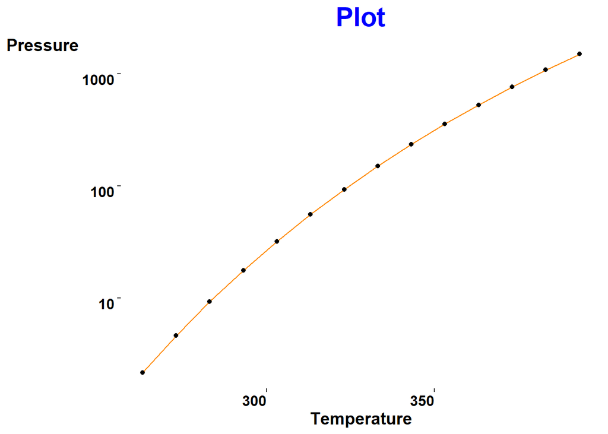

```r
plot1 <- ggplot(df_est, aes(Temperature)) +
  ggtitle("Plot") +
  scale_y_log10() +
  geom_line(aes(y=Pressure), color = "darkorange") +
  geom_point(aes(y=Pressure_est), color = "black") +
  theme(plot.title = element_text(color="#0000FF",
                                    face="bold",
                                    size=22,
                                    hjust=0.5),
          axis.title.x = element_text(size=14,
                                      face="bold",
                                      color="black"),
          axis.title.y = element_text(angle=0,
                                      size=14,
                                      face="bold",
                                      color="black"),
          axis.text.x = element_text(hjust = 1,
                                     face="bold",
                                     color="black",
                                     size=12),
          axis.text.y = element_text(angle=0,
                                     vjust = 1,
                                     face="bold",
                                     color="black",
                                     size=12),
          panel.background = element_blank())
plot1
```

## Rigorous Method

The determination of the coefficients using all of the known data points requires a mathematical method for solving a non-linear equation. The following is the temperature dependent function of the vapor pressure:

$$\begin{equation}
log(VP_{i}) = A -(\frac{B}
{T_{i}+C})
\end{equation}$$

For use in the following mathematical method, this equation **must** be set to equal zero. This can bedone by subtracting the left hand side (the pressure term) from both sides of the equation. The following equation is the result. The set of coefficients could be written as a vector and defined as “X”, with a function of those coefficients written as “f(X)”.

$$\begin{equation}
X_{i} = \left[ \begin{array}{ccc} A_{i} \\ B_{i} \\ C_{i} \end{array} \right]
\end{equation}$$

$$\begin{equation}
f(X_{i}) = log(VP_{i}) - A + (\frac{B}{T_{i}+C}) = 0
\end{equation}$$

The Newton-Raphson method will be used to obtain the coefficients from the vapor pressure equation. This method requires an iterative approach and has the following form[^3].

$$\begin{equation}
X_{i+1} = X_{i} - [\frac{f(X_{i})}{(\frac{df(X_{i})}{dX_{i}})}]
\end{equation}$$

This mathematical method for solving a non-linear equation requires the derivative of this equation. Thus, one would take the above equation, “f(X)”, and differentiate on each of the coefficients in “X”. From this, the first partial derivatives of this vapor pressure function would be the following:

$$\begin{equation}
\frac{\partial f(A,B,C)}{\partial A} = -1
\end{equation}$$

$$\begin{equation}
\frac{\partial f(A,B,C)}{\partial B} = \frac{1}{T_{i}+C}
\end{equation}$$

$$\begin{equation}
\frac{\partial f(A,B,C)}{\partial C} = \frac{B}{(T_{i}+C)^2}
\end{equation}$$

Number of iterations for this example is set to N=100 for j=0 … N. To begin this iterative process, an initial value for temperatue must be defined. For convergence to the actual solution, one should use the values obtained from the quick estimation method.

$$\begin{equation}
\left[ \begin{array}{ccc} A_{0} \\ B_{0} \\ C_{0} \end{array} \right] =
\left[ \begin{array}{ccc} 8.117 \\ 1759 \\ -37.21 \end{array} \right]
\end{equation}$$

This method may not always work well because it may diverge. This divergence may come from the derivative being too close to zero. To prevent this divergence, a scalar type vector () would need to be multiplied to the change portion in the estimation formula. This would look like the following.:

$$\begin{equation}
f(X_{i}) = log(VP_{i}) - A + \epsilon (\frac{B}{T_{i}+C}) = 0
\end{equation}$$

The resulting estimation from this rigorous algorithm would look like the following:

$$\begin{equation}
\left[ \begin{array}{ccc} A_{j+1} \\ B_{j+1} \\ C_{j+1} \end{array} \right] =
\left[ \begin{array}{ccc} A_{j} \\ B_{j} \\ C_{j} \end{array} \right] -
\left[ \begin{array}{ccc} \frac {\epsilon}{A_{j}} \sum_{i}
-[log(VP_{i})-A_{i} + \frac {B_{j}}{T_{i}+C_{i}}]\\
\frac {\epsilon}{B_{j}} \sum_{i}
(T_{i}+C_{j}) [log(VP_{i})-A_{i} + \frac {B_{j}}{T_{i}+C_{i}}] \\
\frac {\epsilon}{C_{j}} \sum_{i}
-(\frac {(T_{i}+C_{j})^2}{{B_{j}}}) [log(VP_{i})-A_{i} + \frac {B_{j}}{T_{i}+C_{i}}]
\end{array} \right]
\end{equation}$$

This rigorous method uses the following to estimate the vapor pressures

$$\begin{equation}
VP_{i} = 10^{(A_{N}- \frac{B_{N}}{T_{i} + C_{N}})}
\end{equation}$$

The following script uses the Newton-Raphson method to calculate theAntoine equation coefficients as a function of the estimate iteration. In my example, I used a value of one for the scalar type vector (), which worked since it did not diverge and explode to large unmanageable values (ie approaching infinity).

```r
N <- 100
M <- length(df_act$Temperature)
epsilon <- 1
A[1] <- A
for (j in 1:N){
  my_sum <- 0
  for (i in 1:M){
    my_sum <- my_sum - (log10(df_act$Pressure[i])-A[j] +
                         B[j]/(df_act$Temperature[i]+C[j]))
  }
  A[j+1] <- A[j] - epsilon * my_sum / A[j] / A[1]
  my_sum <- 0
  for (i in 1:M){
    my_sum <- my_sum + (df_act$Temperature[i]+C[j]) *
      (log10(df_act$Pressure[i])-A[j] +
         B[j]/(df_act$Temperature[i]+C[j]))
  }
  B[j+1] <- B[j] - epsilon * my_sum / B[j] / B[1]
  my_sum <- 0
  for (i in 1:M){
    my_sum <- my_sum +((df_act$Temperature[i]+C[j])^2/B[j]) *
      (log10(df_act$Pressure[i])-A[j] +
         B[j]/(df_act$Temperature[i]+C[j]))
  }
  C[j+1] <- C[j] - epsilon * my_sum / C[j] / C[1^2]
}
antoine <- as.data.frame(cbind(c("A", "B", "C"),
                               c(round(A[1],5),
                                 round(B[1],2),
                                 round(C[1],4)),
                               c(round(A[N],5),
                                 round(B[N],2),
                                 round(C[N],4))))
colnames(antoine) <- c("coeffient", "value_est", "value_newton")
antoine$value_est <- as.numeric(antoine$value_est)
antoine$value_newton <- as.numeric(antoine$value_newton)
antoine$delta <- antoine$value_est - antoine$value_newton
#
# create a flextable
#
ft <- flextable(antoine) %>%
  theme_vanilla() %>%
  set_caption(caption = as_paragraph(
    as_b("Antoine Coefficients")))
ft
```

Antoine Coefficients

| coeffient | value_est | value_newton | delta |
| --- | --- | --- | --- |
| A | 8.11747 | 8.1169 | 0.00057 |
| B | 1,758.99000 | 1,758.9900 | 0.00000 |
| C | -37.21040 | -37.2064 | -0.00400 |

Vapor pressure could be estimated from these results using the following equation:

```r
Estimate <- 10 ^ (A[1] - B[1] / (df_act$Temperature + C[1]))
Newton_Raphson <- 10 ^ (A[N] - B[N] / (df_act$Temperature + C[N]))
df_est <- cbind(df_act, Estimate)
df_est$delta_est <- round((df_est$Pressure - df_est$Estimate), 3)
df_est$Estimate <- round(df_est$Estimate, 3)
df_est <- cbind(df_est, Newton_Raphson)
df_est$delta_NR <- round((df_est$Pressure - df_est$Newton_Raphson), 3)
df_est$Newton_Raphson <- round(df_est$Newton_Raphson, 3)
#

# create a flextable
#
ft <- flextable(df_est) %>%
  bg(i=1, j=3:4, bg="orange", part="header") %>%
  bg(j=3:4, bg="orange", part="body") %>%
  bg(i=1, j=5:6, bg="skyblue", part="header") %>%
  bg(j=5:6, bg="skyblue", part="body") %>%
  theme_vanilla() %>%
  set_caption(caption = as_paragraph(
    as_b("Water Pressures (actual vs. "),
    colorize(as_b("estimate"), color="darkorange"),
    colorize(as_b(" vs. "), color="black"),
    colorize(as_b("Newton-Raphson"), color="blue"),
    colorize(as_b(")"), color="black")))
ft
```

Water Pressures (actual vs. estimate vs. Newton-Raphson)

| Temperature | Pressure | Estimate | delta_est | Newton_Raphson | delta_NR |
| --- | --- | --- | --- | --- | --- |
| 263.15 | 2.149 | 2.149 | 0.000 | 2.147 | 0.002 |
| 273.15 | 4.579 | 4.594 | -0.015 | 4.589 | -0.010 |
| 283.15 | 9.209 | 9.233 | -0.024 | 9.223 | -0.014 |
| 293.15 | 17.535 | 17.570 | -0.035 | 17.552 | -0.017 |
| 303.15 | 31.824 | 31.858 | -0.034 | 31.823 | 0.001 |
| 313.15 | 55.324 | 55.324 | 0.000 | 55.263 | 0.061 |
| 323.15 | 92.510 | 92.437 | 0.073 | 92.334 | 0.176 |
| 333.15 | 149.380 | 149.181 | 0.199 | 149.013 | 0.367 |
| 343.15 | 233.700 | 233.342 | 0.358 | 233.075 | 0.625 |
| 353.15 | 355.100 | 354.792 | 0.308 | 354.382 | 0.718 |
| 363.15 | 525.760 | 525.760 | 0.000 | 525.148 | 0.612 |
| 373.15 | 760.000 | 761.083 | -1.083 | 760.190 | -0.190 |
| 383.15 | 1,074.560 | 1,078.423 | -3.863 | 1,077.148 | -2.588 |
| 393.15 | 1,489.140 | 1,498.447 | -9.307 | 1,496.665 | -7.525 |

## Standard Error of the Estimate

This error reflects the variability of the estimates to the accuracy of the model. This follows the following formula.

$$\begin{equation}
StdError=\sqrt{\frac{\sum_{i}{(Actual_{i}-Estimate_{i})^2}}{M-1}}
\end{equation}$$

```r
SE_estimate <- 0
SE_NR <- 0
for (i in 1:M){
  SE_estimate <- SE_estimate + df_est$delta_est[i]^2
  SE_NR <- SE_NR + df_est$delta_NR[i]^2
}
SE_estimate <- (SE_estimate/(M-1))^0.5
SE_NR <- (SE_NR/(M-1))^0.5
```

**The Standard Error for the quick estimate is 2.815, whereas the Standard Error for the Newton_Rhaphson method is 2.233.**

As seen from the above error results, the rigorous method provides a slightly more accurate representation of the actual data. However, the estimation method values appear to be quite accurate. The rigorous method provides a better representation of the data in that it used all of the known ones in its calculations; whereas, the estimation method only used three data points.

# Notes

[^1]: Haraburda, Scott (March 1, 1996), “[Estimating Vapor Pressures of Pure Liquids](https://www.osti.gov/biblio/212242),” Chemical Engineering volume 103, number 3 pp. 135-136.
[^2]: Dean, John A. (1985), Lange’s Handbook of Chemistry, 13th ed., McGraw-Hill Book Co: New York. See Table 10-6
[^3]: Kreyszig, Erwin. (1988), Advanced Engineering Mathematics, 6th ed., John Wiley & Sons: New York. See section 18.2